**Parameter Estimation in Probabilistic Model**

|  | by Prof. Seungchul Lee iSystems Design Lab http://isystems.unist.ac.kr/ UNIST |
| --- | --- |

Table of Contents

# 1. Generative model

$$ P\left(y \mid X,\omega,\sigma^2 \right) = \mathcal{N}\left(\omega^TX,\sigma^2 \right)$$

[figure not shown]

# 2. Maximum Likelihood Estimation (MLE)

Estimate pramters $\theta\left(\omega,\sigma^2\right)$ such that maximize the likelihood given a generative model

- Given observed data

$$ D=\{(x_1,y_1),(x_2,y_2),\cdots,(x_m,y_m)\}$$

- Generative model structure

$$ \begin{align*} y_i &= \hat{y}_i + \varepsilon \\ &=\omega^T x_i+\varepsilon,\quad \varepsilon \sim \mathcal{N}\left(0,\sigma^2\right) \end{align*} $$

- Find parameters $\omega$ and $\sigma$ that maximize the likelihood over the observed data
- Likelihood:

$$\begin{align*} \mathcal{L}(\omega,\sigma) & = P\left(y_1,y_2,\cdots,y_m \mid x_1,x_2,\cdots,x_m; \; \underbrace{\omega, \sigma}_{\theta}\right)\\ & = \prod\limits_{i=1}^{m} P\left(y_i \mid x_i; \; \omega,\sigma\right)\\ & = \frac{1}{(2\pi\sigma^2)^\frac{m}{2}}\exp\left(-\frac{1}{2\sigma^2}\sum\limits_{i=1}^m(y_i-\omega^T x_i)^2\right) \end{align*}$$

- Perhaps the simplest (but widely used) parameter estimation method

## 2.1. Given $m$ data points, drawn from an exponential distribution

- Exponential distribution from [fundamentals of statistics](http://www.statlect.com/exponential_distribution_maximum_likelihood.htm)

$$f(y)=\frac{1}{a}\exp\left(-\frac{1}{a}y \right)\text{ : generative model}$$
$$\begin{align*} \mathcal{L} & = P\left(y_1,y_2,\cdots,y_m \mid a \right)\\ & = \prod\limits_{i=1}^m\frac{1}{a} \exp\left(-\frac{1}{a}y_i \right)\\ & = \frac{1}{a^m} \exp\left(-\frac{1}{a}\sum\limits_{i=1}^m y_i \right)\\ \\ \text{Log-likelihood} \; \ell &=\text{log} \mathcal{L}=-m\text{log}a-\frac{1}{a}\sum\limits_{i=1}^m y_i \end{align*} $$

- Find $a$ that maximizes $\ell$

$$\frac{d\ell}{da}=-\frac{m}{a}+\frac{1}{a^2}\sum\limits_{i=1}^m y_i = 0 \\ \\ \therefore \;\; a_{ML}=\frac{1}{m}\sum\limits_{i=1}^m y_i \quad :\text{sample mean}$$

```python
import numpy as np
import matplotlib.pyplot as plt
from scipy.stats import norm

%matplotlib inline
```

```python
# exponential random variable
m = 50
x = np.random.exponential(700, (m, 1))  # mu = 700

# MLE
print(1/m*np.sum(x))
```

```
514.030918206
```

## 2.2. Given $m$ data points, drawn from a Gaussian distribution

$$ \begin{align*} P\left(y=y_i \mid \mu,\sigma^2\right) & =\frac{1}{\sqrt{2\pi}\sigma}\exp \left(-\frac{1}{2\sigma^2}(y_i-\mu)^2 \right)\;\text{: generative model}\\\\ \mathcal{L} = P \left(y_1,y_2,\cdots,y_m \mid \mu,\sigma^2 \right) & =\prod\limits_{i=1}^m\frac{1}{\sqrt{2\pi}\sigma}\exp\left(-\frac{1}{2\sigma^2}\left(y_i-\mu\right)^2\right)\\ & = \frac{1}{(2\pi)^\frac{m}{2}\sigma^m}\exp\left(-\frac{1}{2\sigma^2}\sum\limits_{i=1}^m(y_i-\mu)^2 \right)\\\\ \ell =\log \mathcal{L} &=-\frac{m}{2} \text{log}{2\pi}-m \text{log}{\sigma}-\frac{1}{2\sigma^2}\sum\limits_{i=1}^m(y_i-\mu)^2 \end{align*}$$

- To maximize, $\frac{\partial \ell}{\partial \mu}=0, \frac{\partial \ell}{\partial \sigma}=0$

$$ \begin{align*} \frac{\partial \ell}{\partial \mu} &=\frac{1}{\sigma^2}\sum\limits_{i=1}^m(y_i-\mu)=0 \;\; \implies \mu_{ML}=\frac{1} {m}\sum\limits_{i=1}^m y_i \quad \text{: sample mean}\\\\ \frac{\partial \ell}{\partial \sigma} &= -\frac{m}{\sigma}+\frac{1}{\sigma^3}\sum\limits_{i=1}^m(y_i-\mu)^2=0 \;\; \implies \sigma_{ML}^2=\frac{1}{m}\sum\limits_{i=1}^m(y_i-\mu)^2 \quad \text{: sample variance} \end{align*} $$

- BIG Lesson
  - We often compute a mean and variance to represent data statistics
  - We kind of assume that a data set is Gaussian distributed
  - Good news: sample mean is Gaussian distributed by the central limit theorem

**Numerical Simulation**

- Compute the likelihood function, then
  - maximize the likelihood function
  - adjust the mean and variance of the Gaussian to maximize its product

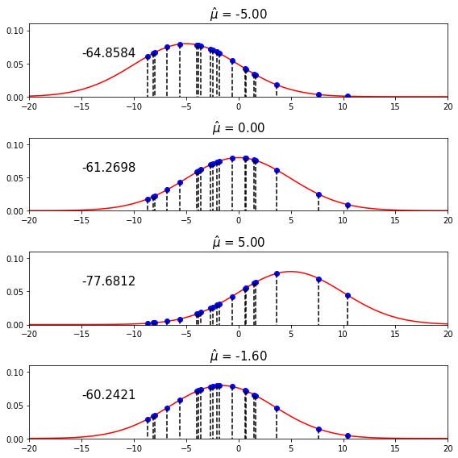

```python
# MLE of Gaussian distribution
# mu

m = 20
mu = 0
sigma = 5

x = np.random.normal(mu,sigma,[m,1])
xp = np.linspace(-20, 20, 100)
y0 = np.zeros([m, 1])

muhat = [-5, 0, 5, np.mean(x)]

plt.figure(figsize=(8, 8))

for i in range(4):
    yp = norm.pdf(xp, muhat[i], sigma)
    y = norm.pdf(x, muhat[i], sigma)
    logL = np.sum(np.log(y))

    plt.subplot(4, 1, i+1)
    plt.plot(xp, yp, 'r')
    plt.plot(x, y, 'bo')
    plt.plot(np.hstack([x, x]).T, np.hstack([y, y0]).T, 'k--')

    plt.title(r'$\hat\mu$ = {0:.2f}'.format(muhat[i]), fontsize=15)
    plt.text(-15,0.06,np.round(logL,4),fontsize=15)
    plt.axis([-20, 20, 0, 0.11])

plt.tight_layout()
plt.show()
```

Compare to a result from formula

$$\mu_{ML}=\frac{1}{m}\sum_{i = 1}^{m}x_i$$

```
0.160329485196
```

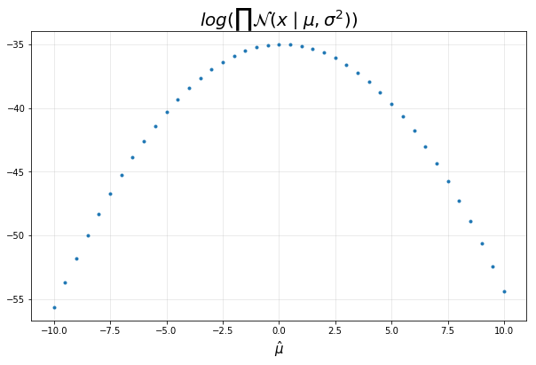

```python
# mean is unknown in this example
# variance is known in this example

m = 10
mu = 0
sigma = 5

x = np.random.normal(mu,sigma,[m,1])

mus = np.arange(-10, 10.5, 0.5)
LOGL = []

for i in range(np.size(mus)):
    y = norm.pdf(x, mus[i], sigma)
    logL = np.sum(np.log(y))
    LOGL.append(logL)

muhat = np.mean(x)
print(muhat)

plt.figure(figsize=(10, 6))
plt.plot(mus, LOGL, '.')
plt.title('$log (\prod \mathcal{N}(x \mid \mu , \sigma^2))$', fontsize=20)
plt.xlabel(r'$\hat \mu$', fontsize=15)
plt.grid(alpha=0.3)
plt.show()
```

$$\sigma_{ML}^2=\frac{1}{m}\sum\limits_{i=1}^m(y_i-\mu)^2$$

```
2.79684136967
```

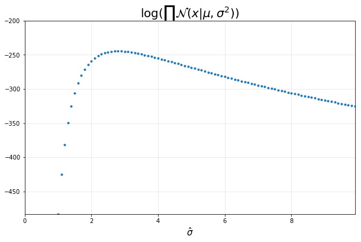

```python
# mean is known in this example
# variance is unknown in this example

m = 100
mu = 0
sigma = 3

x = np.random.normal(mu,sigma,[m,1])  # samples

sigmas = np.arange(1, 10, 0.1)
LOGL = []

for i in range(sigmas.shape[0]):
    y = norm.pdf(x, mu, sigmas[i])     # likelihood
    logL = np.sum(np.log(y))
    LOGL.append(logL)

sigmahat = np.sqrt(np.var(x))
print(sigmahat)

plt.figure(figsize=(10,6))
plt.title(r'$\log (\prod \mathcal{N} (x|\mu,\sigma^2))$',fontsize=20)
plt.plot(sigmas, LOGL, '.')
plt.xlabel(r'$\hat \sigma$', fontsize=15)
plt.axis([0, np.max(sigmas), np.min(LOGL), -200])
plt.grid(alpha=0.3)
plt.show()
```

## 2.3. Linear Regression: A Probablistic View

- Probabilistic Machine Learning
  - I personally believe this is a more fundamental way of looking at machine learning
- Linear regression model with (Gaussian) normal erros

$$ \begin{align*} y &=\omega^T x + \varepsilon, \;\; \varepsilon \sim \mathcal{N}(0,\sigma^2)\\ y - \omega^T x &= \varepsilon \sim \mathcal{N}\left(0,\sigma^2\right)\\ \\ P \left(y_i \mid x_i;\omega,\sigma^2\right) & =\frac{1}{\sqrt{2\pi}\sigma} \exp \left(-\frac{1}{2\sigma^2}\left(y_i-\omega^Tx_i\right)^2 \right) \text{: generative model} \end{align*} $$

$$\begin{align*} \mathcal{L} & = P\left(y_1,y_2,\cdots,y_m \mid \omega,\sigma^2\right)\\ & =\prod\limits_{i=1}^m P\left(y_i \mid x_i; \; \omega,\sigma^2\right) \\ & =\frac{1}{\left(\sqrt{2\pi}\right)^m}\frac{1}{\sigma^m} \exp\left(-\frac{1}{2\sigma^2}\sum\limits_{i=1}^m\left(y_i-\omega^T x_i\right)^2\right)=\text{likelihood} \end{align*}$$

$$\begin{align*} \ell &= -\frac{m}{2}\log{2\pi}-m\log{\sigma}-\frac{1}{2\sigma^2}\sum\limits_{i=1}^m\left(y_i-\omega^T x_i\right)^2\\\\ \frac{d\ell}{d\omega} &=-2X^TY+2X^TX\omega=0\; \implies \; \omega_{ML}=\left(X^TX\right)^{-1}X^TY \quad \text{(look familiar ?)}\\ \frac{d\ell}{d\sigma} & =-\frac{m}{\sigma}+\frac{1}{\sigma^3}\sum\limits_{i=1}^m\left(y_i-\omega^T x_i\right)^2=0 \implies \; \sigma^2_{ML}=\frac{1}{m}\sum\limits_{i=1}^m\left(y_i-\omega^T x_i\right)^2 \end{align*}$$

- BIG Lession
  - same as the least squared optimization

$$\begin{align*} \text{loss function} & =\sum\limits_{i=1}^m\left(y_i-\omega^T x_i\right)^2 \\ & =\|Y-X\omega\|^2_2 \\ & =\left(Y-X\omega\right)^T\left(Y-X\omega\right)\\ & =Y^TY-\omega^TX^TY-Y^TX\omega+\omega^TX^TX\omega\\ \\ \end{align*}$$

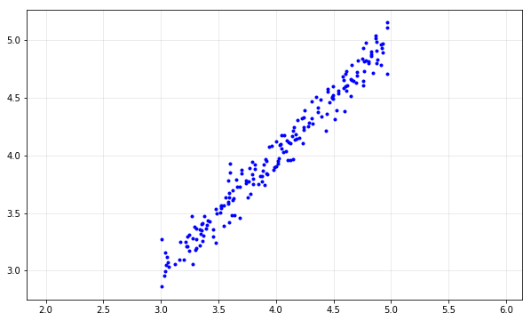

```python
m = 200

a = 1
x = 3 + 2*np.random.uniform(0,1,[m,1])
noise = 0.1*np.random.randn(m,1)

y = a*x + noise;
y = np.asmatrix(y)

plt.figure(figsize=(10, 6))
plt.plot(x, y, 'b.')
plt.axis('equal')
plt.grid(alpha=0.3)
plt.show()
```

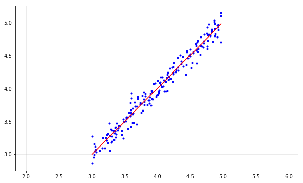

```python
# compute theta(1) and theta(2) which are coefficients of y = theta(1)*x + theta(2)
A = np.hstack([np.ones([m, 1]), x])
A = np.asmatrix(A)

theta = (A.T*A).I*A.T*y

# to plot the fitted line
xp = np.linspace(np.min(x), np.max(x))
yp = theta[1,0]*xp + theta[0,0]

plt.figure(figsize=(10, 6))
plt.plot(x, y, 'b.')
plt.plot(xp, yp, 'r')
plt.axis('equal')
plt.grid(alpha=0.3)
plt.show()
```

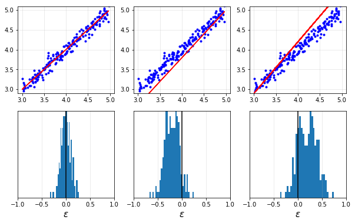

```python
yhat0 = theta[1,0]*x + theta[0,0]
err0 = yhat0 - y

yhat1 = 1.2*x - 1
err1 = yhat1 - y

yhat2 = 1.3*x - 1
err2 = yhat2 - y

plt.figure(figsize=(10, 6))
plt.subplot(2,3,1), plt.plot(x,y,'b.',x,yhat0,'r'), plt.axis([2.9, 5.1, 2.9, 5.1]), plt.grid(alpha=0.3)
plt.subplot(2,3,2), plt.plot(x,y,'b.',x,yhat1,'r'), plt.axis([2.9, 5.1, 2.9, 5.1]), plt.grid(alpha=0.3)
plt.subplot(2,3,3), plt.plot(x,y,'b.',x,yhat2,'r'), plt.axis([2.9, 5.1, 2.9, 5.1]), plt.grid(alpha=0.3)
plt.subplot(2,3,4), plt.hist(err0,31), plt.axvline(0, color='k'), plt.xlabel(r'$\epsilon$', fontsize=15),
plt.yticks([]), plt.axis([-1, 1, 0, 15]), plt.grid(alpha=0.3)
plt.subplot(2,3,5), plt.hist(err1,31), plt.axvline(0, color='k'), plt.xlabel(r'$\epsilon$', fontsize=15),
plt.yticks([]), plt.axis([-1, 1, 0, 15]), plt.grid(alpha=0.3)
plt.subplot(2,3,6), plt.hist(err2,31), plt.axvline(0, color='k'), plt.xlabel(r'$\epsilon$', fontsize=15),
plt.yticks([]), plt.axis([-1, 1, 0, 15]), plt.grid(alpha=0.3)
plt.show()
```

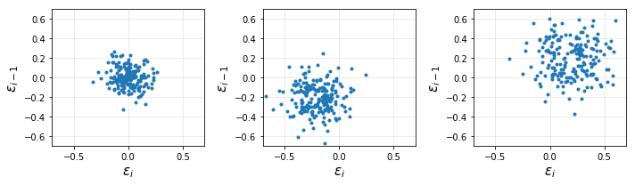

```python
a0x = err0[1:]
a0y = err0[0:-1]

a1x = err1[1:]
a1y = err1[0:-1]

a2x = err2[1:]
a2y = err2[0:-1]

plt.figure(figsize=(10, 3))
plt.subplot(1, 3, 1), plt.plot(a0x, a0y, '.'), plt.axis([-0.7, 0.7, -0.7, 0.7]), plt.grid(alpha=0.3)
plt.xlabel(r'$\epsilon_i$', fontsize=15), plt.ylabel(r'$\epsilon_{i-1}$', fontsize=15)
plt.subplot(1, 3, 2), plt.plot(a1x, a1y, '.'), plt.axis([-0.7, 0.7, -0.7, 0.7]), plt.grid(alpha=0.3)
plt.xlabel(r'$\epsilon_i$', fontsize=15), plt.ylabel(r'$\epsilon_{i-1}$', fontsize=15)
plt.subplot(1, 3, 3), plt.plot(a2x, a2y, '.'), plt.axis([-0.7, 0.7, -0.7, 0.7]), plt.grid(alpha=0.3)
plt.xlabel(r'$\epsilon_i$', fontsize=15), plt.ylabel(r'$\epsilon_{i-1}$', fontsize=15)
plt.tight_layout()
plt.show()
```

## 2.4. Data Fusion with Uncertainties

- [Learning Theory (Reza Shadmehr, Johns Hopkins University)](http://www.shadmehrlab.org/Courses/learningtheory.html)
  - youtube [link](https://www.youtube.com/watch?v=52jlBrAcw9Q)

[output not shown]

- in a matrix form

$$ y = \begin{bmatrix} y_a \\ y_b\end{bmatrix} = Cx+\varepsilon = \begin{bmatrix}1\\1\end{bmatrix}x+\begin{bmatrix}\varepsilon_a\\ \varepsilon_b \end{bmatrix} \quad \quad \varepsilon \sim \mathcal{N}\left(0,R\right),\;\; R=\begin{bmatrix} \sigma^2_a & 0\\ 0 & \sigma^2_b\end{bmatrix}$$

$$\begin{align*}P\left(y \mid x\right) & \sim \mathcal{N}\left(Cx,R\right)\\ &= \frac{1}{\sqrt{\left(2\pi\right)^2\vert R \vert}}\exp\left(-\frac{1}{2}\left(y-Cx\right)^TR^{-1}\left(y-Cx\right)\right)\end{align*}$$

- Find $\,\hat{x}_{ML}$

$$\ell = -\log{2\pi}-\frac{1}{2}\log{\vert R \vert}-\frac{1}{2} \underbrace{\left(y-Cx\right)^TR^{-1}\left(y-Cx\right)}$$

$$ \begin{align*} \left(y-Cx\right)^TR^{-1}\left(y-Cx\right) &= y^TR^{-1}y-y^TR^{-1}Cx-x^TC^TR^{-1}y+x^TC^TR^{-1}Cx \\ \\ \implies \frac{d\ell}{dx} & =0=-2C^TR^{-1}y + 2C^TR^{-1}Cx\\ \therefore \;\; x_{ML} &=\left(C^TR^{-1}C\right)^{-1}C^TR^{-1}y \end{align*} $$

- $ \left(C^TR^{-1}C\right)^{-1}C^TR^{-1} $

$$ \begin{align*} \left(C^TR^{-1}C\right) &= \begin{bmatrix}1 & 1\end{bmatrix}\begin{bmatrix}\frac{1}{\sigma^2_a} & 0 \\ 0 & \frac{1}{\sigma^2_b}\end{bmatrix}\begin{bmatrix}1\\ 1\end{bmatrix} = \frac{1}{\sigma^2_a}+\frac{1}{\sigma^2_b}\\ C^TR^{-1} &= \begin{bmatrix}1 & 1\end{bmatrix}\begin{bmatrix}\frac{1}{\sigma^2_a} & 0 \\ 0&\frac{1}{\sigma^2_b}\end{bmatrix} = \begin{bmatrix}\frac{1}{\sigma^2_a} &\frac{1}{\sigma^2_b} \end{bmatrix}\\ \\ \end{align*} $$

$$\begin{align*} \hat{x}_{ML} &= \left(C^TR^{-1}C\right)^{-1}C^TR^{-1}y = \left(\frac{1}{\sigma^2_a}+\frac{1}{\sigma^2_b}\right)^{-1} \begin{bmatrix}\frac{1}{\sigma^2_a} &\frac{1}{\sigma^2_b} \end{bmatrix} \begin{bmatrix}y_a\\y_b\end{bmatrix} \\&= \frac{\frac{1}{\sigma^2_a}y_a+\frac{1}{\sigma^2_b}y_b}{\frac{1}{\sigma^2_a}+\frac{1}{\sigma^2_b}}\\ \\ \text{var}\left(\hat{x}_{ML}\right) &= \left(\left(C^TR^{-1}C \right)^{-1}C^TR^{-1}\right) \cdot \text{var}(y) \cdot \left( \left(C^TR^{-1}C)^{-1}C^TR^{-1} \right) \right)^T\\ & = \left( \left(C^TR^{-1}C \right)^{-1}C^TR^{-1}\right) \cdot R \cdot \left( \left(C^TR^{-1}C)^{-1}C^TR^{-1} \right) \right)^T\\ &= \left(C^TR^{-1}C \right)^{-1}C^T \cdot \left(R^{-1} \right)^TC \left(\left(C^TR^{-1}C \right)^{-1} \right)^T \\ &=\underbrace{\left(C^TR^{-1}C\right)^{-1}} \underbrace{C^TR^{-1}C}\left(\left(C^TR^{-1}C\right)^{-1}\right)^T = \left(C^TR^{-1}C\right)^{-1}\\\\ &=\frac{1}{\frac{1}{\sigma^2_a}+\frac{1}{\sigma^2_b}} \leq \;\; \sigma^2_a,\;\sigma^2_b \end{align*}$$

- summary

$$ \begin{align*} \hat{x}_{ML} &= \frac{\frac{1}{\sigma^2_a}y_a+\frac{1}{\sigma^2_b}y_b}{\frac{1}{\sigma^2_a}+\frac{1}{\sigma^2_b}}\\ \text{var}\left(\hat{x}_{ML}\right) &= \frac{1}{\frac{1}{\sigma^2_a}+\frac{1}{\sigma^2_b}} \leq \;\; \sigma^2_a,\;\sigma^2_b \end{align*} $$

- BIG Lesson:
  - two sensors are better than one sensor $\implies$ less uncertainties
  - accuracy or uncertainty information is also important in sensors

[figure not shown]

**Example of two rulers**

- 1D example
- how brain works on human measurements from both *haptic* and *visual* channels

[figure not shown]

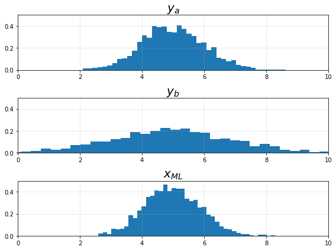

```python
x = 5       # true state (length in this example)
a = 1       # sigma of a
b = 2      # sigma of b

YA = []
YB = []
XML = []

for i in range(2000):
    ya = x + np.random.normal(0,a)
    yb = x + np.random.normal(0,b)
    xml = (1/a**2*ya + 1/b**2*yb)/(1/a**2+1/b**2)
    YA.append(ya)
    YB.append(yb)
    XML.append(xml)

plt.figure(figsize=(8, 6))
plt.subplot(3, 1, 1), plt.hist(YA, 41, normed=True), plt.axis([0, 10, 0, 0.5]),
plt.title(r'$y_a$', fontsize=20), plt.grid(alpha=0.3)
plt.subplot(3, 1, 2), plt.hist(YB, 41, normed=True), plt.axis([0, 10, 0, 0.5]),
plt.title(r'$y_b$', fontsize=20), plt.grid(alpha=0.3)
plt.subplot(3, 1, 3), plt.hist(XML, 41, normed=True), plt.axis([0, 10, 0, 0.5]),
plt.title(r'$x_{ML}$', fontsize=20), plt.grid(alpha=0.3)
plt.tight_layout()
plt.show()
```

**Example of two GPSs**

- 2D example

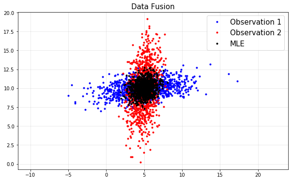

```python
x = np.array([5, 10]).reshape(-1, 1) # true position

mu = np.array([0, 0])
Ra = np.matrix([[9, 1],
               [1, 1]])
Rb = np.matrix([[1, 1],
                [1, 9]])

YA = []
YB = []
XML = []

for i in range(1000):
    ya = x + np.random.multivariate_normal(mu, Ra).reshape(-1, 1)
    yb = x + np.random.multivariate_normal(mu, Rb).reshape(-1, 1)
    xml = (Ra.I+Rb.I).I*(Ra.I*ya+Rb.I*yb)
    YA.append(ya.T)
    YB.append(yb.T)
    XML.append(xml.T)

YA = np.vstack(YA)
YB = np.vstack(YB)
XML = np.vstack(XML)

plt.figure(figsize=(10, 6))
plt.title('Data Fusion', fontsize=15)
plt.plot(YA[:,0], YA[:,1], 'b.', label='Observation 1')
plt.plot(YB[:,0], YB[:,1], 'r.', label='Observation 2')
plt.plot(XML[:,0], XML[:,1], 'k.', label='MLE')
plt.axis('equal')
plt.grid(alpha=0.3)
plt.legend(fontsize=15)
plt.show()
```

# 3. Maximum-a-Posterior Estimation (MAP)

- Choose $\theta$ that maximizes the posterior probability of $\theta$ (*i.e.* probability in the light of the observed data)
- Posterior probability of $\theta$ is given by the Bayes Rule
  $$P(\theta \mid D) = \frac{P(D \mid \theta)P(\theta)}{P(D)}$$
  - $P(\theta)$: Prior probability of $\theta$ (without having seen any data)
  - $P(D \mid \theta)$: Likelihood
  - $P(D)$: Probability of the data (independent of $\theta$)

$$ P(D) = \int P(\theta)P(D \mid \theta) d\theta $$

- The Bayes rule lets us update our belief about $\theta$ in the light of observed data
- While doing MAP, we usually maximize the log of the posterior probability

$$\begin{align*} \theta_{MAP} = \underset{\theta}{\mathrm{argmax}}\;\;P(\theta \mid D) &= \underset{\theta}{\mathrm{argmax}}\;\;\frac{P(D \mid \theta)P(\theta)}{P(D)}\\ & =\underset{\theta}{\mathrm{argmax}} \;\; P(D \mid \theta)P(\theta)\\ & = \underset{\theta}{\mathrm{argmax}} \;\; \log P(D \mid \theta)P(\theta)\\ & = \underset{\theta}{\mathrm{argmax}} \;\; \left\{\log{P \left(D \mid \theta \right)} + \log{P(\theta) }\right\}\end{align*}$$

- for multiple observations $D = \{d_1,d_2,\cdots,d_m\}$

$$ \theta_{MAP} = \underset{\theta}{\mathrm{argmax}} \;\; \left\{\sum_{i=1}^{m}\log{P \left(d_i \mid \theta \right)} + \log{P(\theta) }\right\} $$

- same as MLE except the extra log-prior-distribution term
- MAP allows incorporating our prior knowledge about $\theta$ in its estimation

| $$\theta_{MAP} = \underset{\theta}{\mathrm{argmax}}\;\;P(\theta \mid D)$$ | $$ \theta_{MLE} = \underset{\theta}{\mathrm{argmax}}\;\;P(D \mid \theta) $$ |
| --- | --- |

## 3.1. MAP for mean of a univariate Gaussian, $\mathcal{N}(\theta,\sigma^2)$

Suppose that $\theta$ is a random variable with $\theta \sim \mathcal{N}(\mu,1^2)$, but a prior knowledge (unknown $\theta$ and known $\mu, \; \sigma^2$)

- Observations $ D=\{x_1,x_2,\cdots,x_m\}: \text{conditionally independent given}\; \theta$

$$ x_i \sim \mathcal{N}(\theta,\sigma^2) $$

- Joint Probability

$$ P(x_1,x_2,\cdots,x_m \mid \theta) = \prod\limits_{i=1}^m P(x_i \mid \theta) $$

- MAP: choose $\theta_{MAP}$

$$\begin{align*} \theta_{MAP} &= \underset{\theta}{\mathrm{argmax}}\;\;P(\theta \mid D)=\frac{P(D \mid \theta)P(\theta)}{P(D)}\\ & = \underset{\theta}{\mathrm{argmax}} \;\; P(D \mid \theta)P(\theta)\\ & = \underset{\theta}{\mathrm{argmax}} \;\; \left\{\log{P \left(D \mid \theta \right)} + \log{P(\theta) }\right\}\end{align*}$$

$$\begin{align*} \frac{\partial}{\partial \theta} \left(\log{P \left(D \mid \theta \right)} \right) & =\; \cdots \; = \frac{1}{\sigma^2} \left(\sum\limits_{i=1}^m x_i-m\theta \right)\quad (\text{we did in MLE})\\ \\ \frac{\partial}{\partial \theta} \left(\log{P \left(\theta \right)} \right) &=\frac{\partial}{\partial\theta} \left(\log \left(\frac{1}{\sqrt{2\pi}}e^{-\frac{1}{2}(\theta-\mu)^2} \right) \right)\\ & \; \vdots \\ &=\frac{\partial}{\partial\theta} \left(-\frac{1}{2}\log{2\pi}-\frac{1}{2} \left(\theta - \mu \right)^2 \right)\\ & =\mu-\theta \end{align*}$$

$$\begin{align*} \implies & \frac{\partial}{\partial \theta} \left(\log{P \left(D \mid \theta \right)} \right) + \frac{\partial}{\partial \theta} \left(\log{P \left(\theta \right)} \right)\\ & = \frac{1}{\sigma^2}\left(\sum\limits_{i=1}^m x_i - m\theta^* \right) + \mu - \theta^* = 0 \\ & = \frac{1}{\sigma^2}\sum\limits_{i=1}^m x_i + \mu - \left(\frac{m}{\sigma^2}+1\right)\theta^* = 0 \\ \theta^* &= \frac{\frac{1}{\sigma^2}\sum\limits_{i=1}^m x_i + \mu}{\frac{m}{\sigma^2}+1} = \frac{\frac{m}{\sigma^2}\cdot\frac{1}{m}\sum\limits_{i=1}^m x_i+1\cdot\mu}{\frac{m}{\sigma^2}+1} \end{align*}$$

$$\therefore \;\theta_{MAP} = \frac{\frac{m}{\sigma^2}}{\frac{m}{\sigma^2}+1}\bar{x}+\frac{1}{\frac{m}{\sigma^2}+1}\mu \;\;\;\text{: look familiar ?}$$

- ML interpretation:

$$\begin{align*} &\begin{cases} \mu = \text{prior mean}\\ \bar{x} = \text{sample mean} \end{cases} \\ &\begin{cases} \mu = 1\text{st} \;\;\text{observation} \; \sim \mathcal{N}\left(0,1^2\right)\\ \bar{x} = 2\text{nd}\;\; \text{observation} \; \sim \mathcal{N}\left(0,\left(\frac{\sigma}{\sqrt{m}}\right)^2\right) \end{cases} \\ \end{align*}$$

- BIG Lesson: a prior acts as a data

[figure not shown]

**Note:** prior knowledge

- Education
- Get older
- School ranking

Example) Experiment in class

- Which one do you think is heavier?
  - with eyes closed
  - with visual inspection
  - with haptic (touch) inspection

[figure not shown]

## 3.2. MAP Python code

Suppose that $\theta$ is a random variable with $\theta \sim \mathcal{N}(\mu,1^2)$, but a prior knowledge (unknown $\theta$ and known $\mu, \; \sigma^2$)

$$ x_i \sim \mathcal{N}(\theta,\sigma^2) $$

- for mean of a univariate Gaussian

```python
# known
mu = 5
sigma = 2

# unknown theta
theta = np.random.normal(mu,1)
x = np.random.normal(theta, sigma)

print('theta = {:.4f}'.format(theta))
print('x = {:.4f}'.format(x))
```

```
theta = 3.8211
x = 5.7443
```

$$\theta_{MAP} = \frac{\frac{m}{\sigma^2}}{\frac{m}{\sigma^2}+1}\bar{x}+\frac{1}{\frac{m}{\sigma^2}+1}\mu $$

```python
# MAP

m = 4
X = np.random.normal(theta,sigma,[m,1])

xbar = np.mean(X)
theta_MAP = m/(m+sigma**2)*xbar + sigma**2/(m+sigma**2)*mu

print('mu = 5')
print('xbar = {:.4f}'.format(xbar))
print('theta_MAP = {:.4f}'.format(theta_MAP))
```

```
mu = 5
xbar = 2.2625
theta_MAP = 3.6313
```

```
theta = 6.1839
```

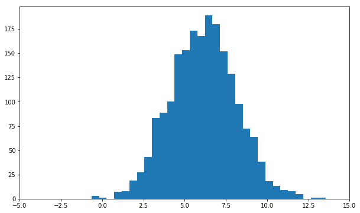

```python
# theta
mu = 5
theta = np.random.normal(mu,1)

sigma = 2
m = 2000

X = np.random.normal(theta,sigma,[m,1])
X = np.asmatrix(X)

print('theta = {:.4f}'.format(theta))
plt.figure(figsize=(10,6))
plt.hist(X,31)
plt.xlim([-5,15])
plt.show()
```

```
theta = 6.1839
```

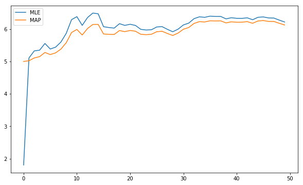

```python
n = 50
XMLE = []
XMAP = []

for k in range(n):
    xmle = np.mean(X[0:k+1,0])
    xmap = k/(k+sigma**2)*xmle + sigma**2/(k + sigma**2)*mu
    XMLE.append(xmle)
    XMAP.append(xmap)

print('theta = {:.4f}'.format(theta))
plt.figure(figsize=(10,6))
plt.plot(XMLE)
plt.plot(XMAP)
plt.legend(['MLE','MAP'])
plt.show()
```

## 3.3. Object Tracking in Computer Vision

- Optional
- Lecture: Introduction to Computer Vision by Prof. Aaron Bobick at Georgia Tech

```python
%%html
<center><iframe src="https://www.youtube.com/embed/rf3DKqWajWY?rel=0"
width="560" height="315" frameborder="0" allowfullscreen></iframe></center>
```

[video not shown]

```python
%%html
<center><iframe src="https://www.youtube.com/embed/5yUjYCkm2jI?rel=0"
width="560" height="315" frameborder="0" allowfullscreen></iframe></center>
```

[video not shown]

# 4. Kernel Density Estimation

- *non-parametric* estimate of density
- Lecture: Learning Theory (Reza Shadmehr, Johns Hopkins University)

```python
%%html
<center><iframe src="https://www.youtube.com/embed/a357NoXy4Nk?rel=0"
width="560" height="315" frameborder="0" allowfullscreen></iframe></center>
```

[video not shown]

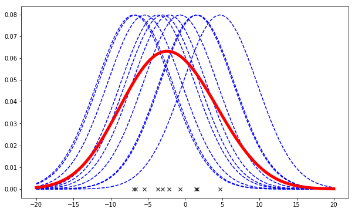

```python
m = 10
mu = 0
sigma = 5

x = np.random.normal(mu,sigma,[m,1])
xp = np.linspace(-20,20,100)
y0 = np.zeros([m,1])

X = []

for i in range(m):
    X.append(norm.pdf(xp,x[i,0],sigma))

X = np.array(X).T
Xnorm = np.sum(X,1)/m

plt.figure(figsize=(10,6))
plt.plot(x,y0,'kx')
plt.plot(xp,X,'b--')
plt.plot(xp,Xnorm,'r',linewidth=5)
plt.show()
```